# Lab 4: NYC flights

In this lab, we will explore a random sample of domestic flights that departed from the three major New York City airports in 2013. We will be building on the tools that we have learned so far. As always, you will be writing up your answers to the questions marked as exercises in your lab report.

**Learning Objectives**

- Gain more experience using `filter`, `select`, `mutate` and `arrange`, `count`, `group_by` and `summarize`
- Practice making plots using `ggplot`

## Getting started

Access JupyterHub from CANVAS as you have done before. Create a new lab report template to save your answers to the exercises as we have done before. Be sure to personalize the header with the title of the lab and also add your name.

### Packages

In this assignment we will work with the **tidyverse** and **openintro** packages. The code to attach them is in the setup code chunk of your lap report template. Go ahead and run the code in your Console as you have done in previous labs.

```r
library(tidyverse)
library(openintro)
```

## The Data

The [Bureau of Transportation Statistics](http://www.rita.dot.gov/bts/about/) (BTS) is a statistical agency that is a part of the Research and Innovative Technology Administration (RITA). As its name implies, BTS collects and makes transportation data available, such as the flights data we will be working with in this lab.

Load the `nycflights` data frame and take a look at the contents.

```r
data(nycflights)  #type in Console
```

A description of the data and variables can be found by accessing the help pages:

```r
?nycflights #type in Console
```

Write answers to questions marked as exercises within your Rmarkdown document.

1. What are the five most common destinations for flights from NYC in 2013? Make a table that lists them in descending order of frequency and shows the number of fights heading to each airport. In your *narrative* following the output, mention the names of the top five destination cities. (Google is your friend)

The `nycflights` data frame is a massive trove of information. Let’s think about some questions we might want to answer with these data:

- How delayed were the flights that were headed to Los Angeles?
- How do departure delays to Los Angeles vary by month?
- How do departure delays to Los Angeles vary by carrier?

The first question involves just one variable at a time (delay time), while the second two questions involve relationships between variables. Below, we will first explore univariate summaries of the data, and then we will dive in to relationships between variables.

## Analysis

### Departure Delays

As indicated in the helpfiles, the departure and arrival delays are measured in minutes. Negative times represent early departures/arrivals.

Let’s start by visually examining the distribution of departure delays of all flights. Type the following code and in your Console and then run it.

```r
#type in Console

ggplot(data = nycflights, mapping=aes(x = dep_delay)) +
  geom_histogram( binwidth = 10) +
  labs(title="Departure delays for NYC flights 2013",
       subtitle="All flights",
       x="Departure delay (mins)")
```

This function says to plot the `dep_delay` variable from the `nycflights` data frame on the x-axis. It also defines a `geom` (short for geometric object), which describes the type of plot you will produce.

If you submit the plotting code to the Console, you should see the plot appear under the *Plots* tab of the lower right panel of RStudio.

We can use the powerful `ggplot()` function from the `ggplot2` package to build all sorts of plots.

For instance, suppose we want to visualize how departure delays correlate with the arrival delays, we might run something like the following. Type the following code in your Console and then run it.

```r
#type in Console

ggplot(data = nycflights,
       mapping=aes(x = dep_delay, y = arr_delay)) +
    geom_point() +
    labs(title="Arrival versus departure delay",
         subtitle = "All flights" ,
         x = "Departure Delay (mins)",
         y = "Arrival Delay (mins)" )
```

The format of the code to build different types of plots with `ggplot()` tends to follow a similar pattern.

- The first argument is always the data set.
- Next, you provide the variables from the data set to be assigned to `aes`thetic elements of the plot, e.g. the x and the y axes. For a univariate display, we only have an x variable.
- Then you use another layer, separated by a `+` to specify the `geom`etric object for the plot. When we want a histogram, we use `geom_histogram`, for a scatter plot we use `geom_point`, `geom_boxplot` for a boxplot, etc.
- Specific types of plots have their own unique extra arguments. For a histogram, we can specify the binwidth<sup>1</sup>. As with many R functions, one can also opt to go with the default choice and not specify any arguments.
- Additional layers can be added to customize the scales, create titles, select color palettes, etc.
2. Consider the set of flights headed to LAX in February. Make a histogram of the distribution of the arrival delays (`arr_delay`) of these flights. You should try different binwidths and pick one that creates a plot which is not overly smooth or overly choppy. Be sure to give a title, subtitle for your plot and a meaningful label for the x axis. No sentence needed, just the output.

   *Hint: you can filter within the `data` argument in the `ggplot` function. See example code before Exercise 4 if you are stuck*

In addition to visual summaries, we will often find it useful to summarize our data numerically. Type the following code in your Console and run it.

```r
#type in Console

nycflights %>%
  summarize(mean_dd = mean(dep_delay),
            median_dd = median(dep_delay),
            sample_size = n())
```

Note that in the `summarize` function we simultaneously created a list of three different numerical summaries that we were interested in. Calculating these summary statistics requires that you know the correct function names such as `mean()`, `median()` etc. The names given to the results are user defined, like `mean_dd`, `median_dd`, `sample_size`, and you can customize them as you like (just don’t use spaces in your names).

The function `n()` from dplyr calculates the current group size.

As a reminder, the functions you can use within `summarise` are shown below.

**Summary statistics:** Some useful function calls for summary statistics for a single numerical variable are as follows:

- `sum`
- `mean`
- `median`
- `sd`
- `var`
- `IQR`
- `min`
- `max`
- `n()`

Each of these functions takes a single vector as an argument and returns a single value.

3. Calculate the min, mean, median, max of `arr_delay` for the LAX February Flights. Just code, no written sentence is needed.

### Departures delays by month

Which month would you expect to have the highest average departure delay?

We could make use of faceting in order to examine the distribution of `dep_delay` by month. Type the following code in your Console and run it.

```r
#type in Console

ggplot(data=nycflights, mapping = aes(x=dep_delay) ) +
  geom_histogram(binwidth = 10) +
  facet_wrap(~month) +
     labs(title="Departure delays of NYC flights",
          subtitle="Faceted by month",
          x = "Departure delay (mins)")
```

The extreme skewness of the `dep_delay` variable results in histograms that are concentrated in a small area of each facet. One way to rectify this is to filter the data to only include `dep_delay < 100` so we can take a closer look in the region where most of the data lie as shown below. Try it!

```r
#type in Console

ggplot(data=nycflights %>% filter(dep_delay < 100),
       mapping = aes(x=dep_delay) ) +
        geom_histogram(binwidth = 10) +
            facet_wrap(~month) +
     labs(title="Departure delays of NYC flights",
          subtitle="Faceted by month",
          x = "Departure delay (mins)")
```

4. Adapt the code in the previous code chunk to create a faceted histogram of flights headed to Los Angeles, where each facet represents a month and displays `dep_delay` for that month. Experiment with different cutoffs for filtering the data so you get a nice close-up view of the body of the histogram. Also don’t forget to revise the title.

Now let’s think about how you could numerically answer the question posed at the start of this section. Which month would you expect to have the highest average departure delay? With the new language you are learning, this means you need to

- `group_by` months, then
- `summarize` the average departure delay.
- `arrange` these average delays in `desc`ending order to easily see which month has the most delayed departures.
5. Consider the set of flights headed to Los Angeles. Based on the mean, list the top two months with the longest average departure delay? Write your answer in a complete sentence.

### Departure delays by carrier

Suppose you want to compare the departure delays by origin airport. A box plot could provide a useful visual approach for comparing these distributions. Run the following in the Console.

```r
#type in Console

ggplot(data = nycflights,
       mapping=aes(x=dep_delay, fill=origin)) +
  geom_boxplot() +
  labs(title="Departure Delay by origin airport",
       x="Departure delay (mins)",
       fill="Airport")+
  theme(
    axis.ticks.y=element_blank(),
    axis.text.y=element_blank()
  )+
  scale_fill_viridis_d()
```

The `fill` variable must be a character variable and it enables us to view the distribution of `dep_delay` by the origin airport. Note that we also customized the legend of the fill variable, and picked a color palette for the fill variable which is perceptible to viewers with common forms of color blindness. The $y$ axis in a box plot such as this is not really meaningful and the `theme` layer enables us to render it as such.

6. Suppose you are planning a trip from NYC to LAX and you want to pick the carrier with the least departure delays. Make a box plot to compare the `dep_delay` by `carrier`. Which carrier would you pick? **Write your answer in a complete sentence and also explain your reasoning for picking the carrier you did .** Be sure to customize the $y$ axis appropriately, use the viridis palette and also label your plot carefully.

The carrier (airline) variable is coded according to the following system.

- `carrier`: Two letter carrier abbreviation.
  - `9E`: Endeavor Air Inc.
  - `AA`: American Airlines Inc.
  - `AS`: Alaska Airlines Inc.
  - `B6`: JetBlue Airways
  - `DL`: Delta Air Lines Inc.
  - `EV`: ExpressJet Airlines Inc.
  - `F9`: Frontier Airlines Inc.
  - `FL`: AirTran Airways Corporation
  - `HA`: Hawaiian Airlines Inc.
  - `MQ`: Envoy Air
  - `OO`: SkyWest Airlines Inc.
  - `UA`: United Air Lines Inc.
  - `US`: US Airways Inc.
  - `VX`: Virgin America
  - `WN`: Southwest Airlines Co.
  - `YV`: Mesa Airlines Inc.

## More Practice

Work on these problems to stretch yourself. They do not need to be turned in, so be sure to put them in hidden code chunks.

- Mutate the data frame `nycflights` so that it includes a new variable that contains the speed, `speed` traveled by the plane for each flight (in mph). **Hint:** Speed can be calculated as distance divided by number of hours of travel, and note that `air_time` is given in minutes.
- Make a scatter plot of `speed` vs. `distance`. **Hint:** Use `geom_point()`.
- Replicate the following plot. **Hint:** The data frame plotted only contains flights from American Airlines (AA), Delta Airlines (DL), and United Airlines (UA), and the points are `color` coded by `carrier`.

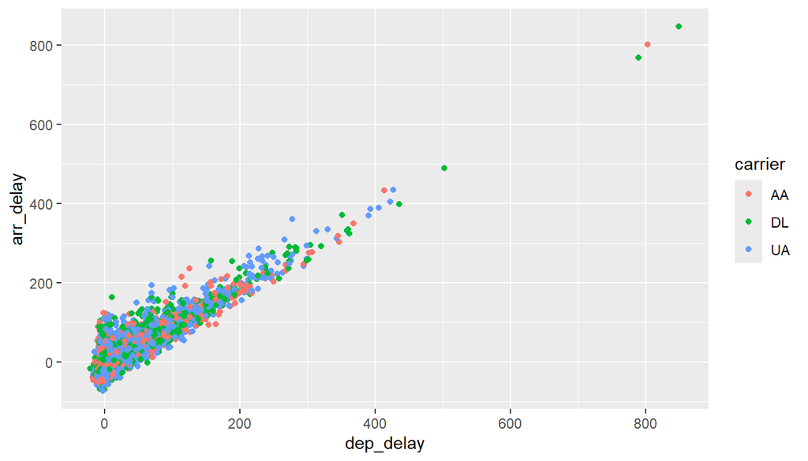

## Conclusion

Congratulations! This concludes Lab 4. Be sure to turn in both your `.Rmd` and `.html` files **separately** in CANVAS. Remember it is your responsibility to make sure the right files are uploaded.

## Acknowledgments

This lab is a modified version of Lab 2 (Introduction to Data) from the [OpenInto Labs](https://github.com/OpenIntroStat/oilabs-tidy).

This is a product of OpenIntro that is released under a [Creative Commons Attribution-ShareAlike 3.0 Unported](http://creativecommons.org/licenses/by-sa/3.0).

<sup>1. There are many rules of thumb for specifying the binwidth. One popular one is to calculate the **number of bins** as $\log_2(n)$ where $n$ is the number of observations and rounding up. Then calculate the binwidth by dividing the range of the data by the number of bins.</sup>